# A Titanic Introduction to R

## Workbook

- You can run the code in these slides by opening `01-introduction-to-r.R` and following along.
- **ALL** of the code you see on the screen today is in your workbook.
- You will learn more if you see the code run for yourself.
  - *This is technically an untested hypothesis. Sorry.*

## Learning Objectives

- RStudio
- R Semantics, Structure, Etc.
- Getting Help
- Atomic Data Types
- Vectors

## First Steps In R

## Starting RStudio

- Click on the RStudio icon.
- Open the R Script you would like to run: `01-introduction-to-r.R`
- Sink a very large boat. *(Not technically necessary.)*

#### Questions

- Is anyone NOT using RStudio today?
- Does anyone need help getting RStudio / R to start?

## RStudio: Screenshot 1

[figure not shown]

## RStudio: Screenshot 2

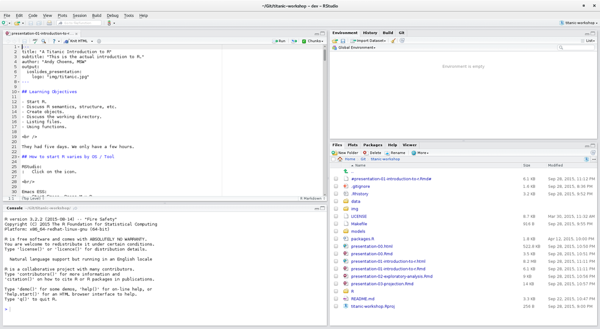

## Two ways to run code:

#### REPL

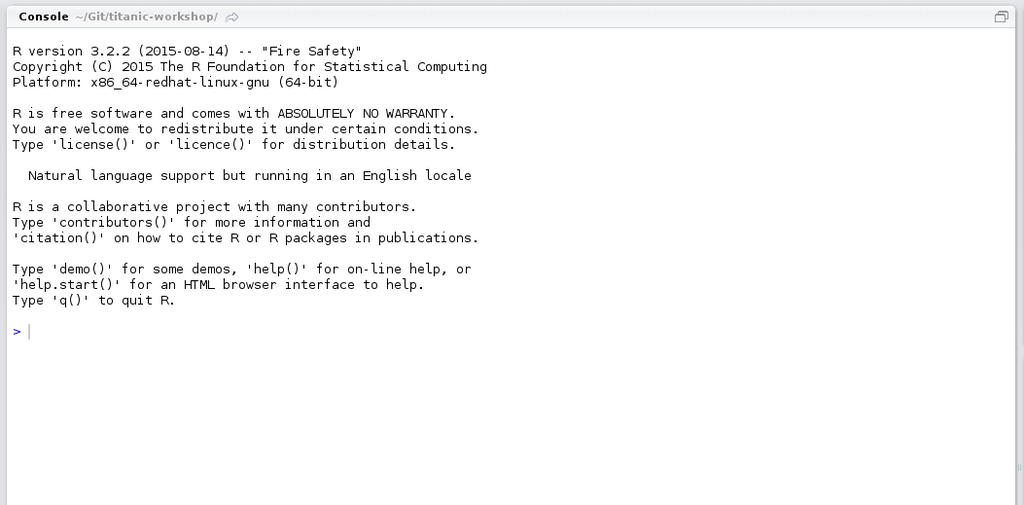

#### R Scripts

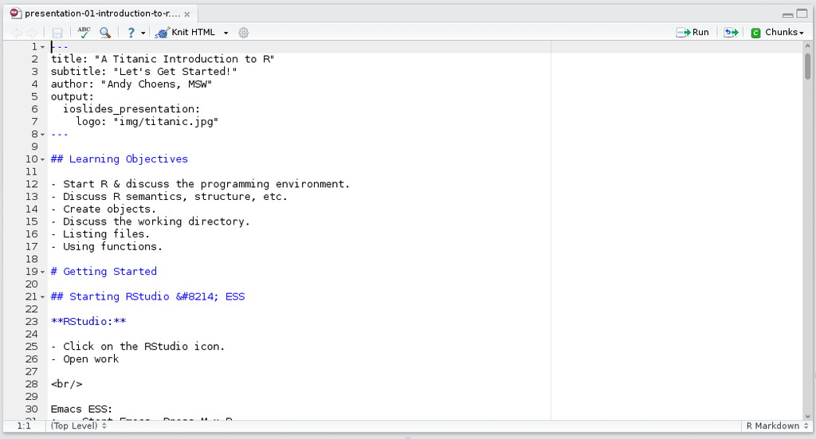

[figure not shown]

## An Overly Complicated Calculator

- R is a great calculator.
- PLEASE tell us know if you can't find this code in the  
  `01-introduction-to-r.R` workbook.
- Now that you have found it - **You try it!**

```r
## You can use R as an over-powered calculator.
## Type the following into the REPL console or run them from the
## 01-introduction-to-r.R script.

1 + 1

sqrt(9)             ## sqrt() is a function.

sqrt(1+5+6-3)       ## We can pass values to functions and get results.
```

## Practice: Calculator

This is our first visit from Captain Smith.

```r
## What is the value of (1+2)*(1+1+1) ?

## Write the "equation" here and run it.
```

Answer:

- [1] 9

## Assignment Operators

**NOTE:** You should run this code with me.

```r
## The equals sign can be used to assign value to a variable.
a = 1
a
```

Returns:

- [1] 1

```r
## But the preferred assignment operator is "<-".
## RStudio Shortcut: [Alt] [-] will insert the R assignment operator.

a <- 1
a
```

Returns:

- [1] 1

## Practice: Assignment Operator

```r
## Create a variable "sank" and give it a value of "1912".

## Replace this comment with some code.
```

Correct Answers: *(No Peeking!)*

- `sank <- 1912`
- `sank <- "1912"`

## Atomic Data Types

## Atomic Data Types - Numeric

- R has extensive support for different types of numbers.
- R can also handle imaginary numbers and other fun mathematical oddities.
- Today, we are going to keep it "real" and focus on simple things.

```r
## Numeric -----------------------------
pi <- 3.14159

## We can confirm this:
typeof(pi)          ## This is a function we will use again.
```

Returns:

- `[1] "double"`

## Atomic Data Types - Funny Integers

- **Question:** Are you running this code as I do?
- **Best Answer:** Yes!

```r
## Integers are funny. They have to be created consciously.
starboard <- 10
typeof(starboard)           ## I told you. This is a useful function.
```

Returns:

- `[1] "double"`
- Yes, 10 **IS** an integer but R is treating like a decimal.

## Atomic Data Types - Integers

```r
## Integers must be created consciously.
starboard <- as.integer(10)
typeof(starboard)
```

Returns:

- `[1] "integer"`

```r
## We can (double) confirm this:
is.integer(starboard)
```

Returns:

- `[1] TRUE`
- **Question:** Why would R have this behavior?
- **Answer:** R tries to give your variables the "right" type.

## Numerics ARE Safer

```r
## Question: What is the assigned value of foo?
port <- as.integer(10)
port
```

Answer:

- `[1] 10`

```r
## Question: What is the assigned value of foo?
port <- as.integer(3.14159)
port
```

Answer:

- `[1] 3`
- The decimal, 3.14159, was coerced to an integer.
- R floors decimal values. It does NOT round them.

## Numerics ARE Safer

```r
## Question: What is the assigned value of foo?
port <- 3.3 * 4
port
```

Answer:

- [1] 13.2

```r
## Question: What is the assigned value of foo?
port <- as.integer(3.3) * 3
port
```

Answer:

- [1] 9

## Numerice ARE Safer: Discussion

- Avoid integers unless you KNOW it is an integer.
- Many programming languages will make integers into integers and then do integer math, even when you don't want it to.
- R hates you less.
- Don't look like this guy.

[figure not shown]

## Atomic Data Types - LOGICAL

```r
## LOGICAL variables are often created in the process of comparing things.
starboard <- 10; port <- 15;

## Question: Is this TRUE or FALSE?
starboard <= port   ## Yeah - It is a little nonsensical.
```

Answer:

- `[1] TRUE`

```r
## Question: Is this TRUE or FALSE?
port = starboard
```

Answer:

- NEITHER!!!
- This is the equivalent of: `port <- 10`!
- To compare things, we need slightly different syntax. . . .

## Atomic Data Types - LOGICAL

```r
## LOGICAL variables are often created in the process of comparing things.
starboard <- 10; port <- 15;

## THIS IS HOW YOU COMPARE THINGS!
starboard == port
```

Returns:

- `[1] FALSE`
- Comparison operators: `<`, `>`, `==`, `<=`, `>=`, `|`, `!`

## Atomic Data Types - CHARACTER

- Andy likes to call "character" variables "string" vars.
- He profusely apologizes in advance.

```r
## You can use " or ' to create a character.
## There are subtle differences, mostly if your variable has
## either in it.

## Some character vars:
first_name <- "Captain"
last_name <- "Smith"

## Let's put them together!
paste(first_name, last_name, sep=" ")
```

Returns:

- `[1] "Captain Smith"`
- We will learn additional functions for working with character variables as we go.

## Atomic Data Types - DATES

```r
## POSIX Dates are EASY!
## Like an integer, you have to be explicit.
aft <- as.Date("2015-01-01")

## typeof
typeof(aft)         ## typeof may return something you don't expect.
```

Returns:

- `[1] "double"`
- Stored internally as a number.

```r
## Kinda looks like a character var.
aft
```

Returns:

- `[1] "2015-01-01"`
- But it LOOKS like a date when we look at it.

## Practice: Atomic Data Types

- The Captain *(once again)* thinks it is YOUR turn to write some code.

```r
## 1: Create an variable called "my_age" and then
##    assign it an integer equal to your age.

## 2: Using the following code, which is bigger (later)? a_day or today?

## This creates two date vars.
a_day <- as.Date('2015-06-30')
today <- Sys.Date()

## Use this space to compare a_day to today.
##
```

Example Answers:

- `my_age <- 36`
- `a_day < today` which returns: `[1] TRUE`
- There are, obviously, other possible answers.

## Vectors

- Vectors are a 1-dimensional data set in R.
- They have two important attributes:
  - Data Type (can be ANY)
  - Length

```r
yard_arm <- c(1,2,3,4,5)      ## The Titanic's maiden voyage
                              ## lasted for five days.
yard_arm
```

Returns:

- [1] 1 2 3 4 5
- The "atomic" variables we created earlier? Just vectors with length 1.

## Vectors - Length

```r
## The variable yard_arm has five distinct values in it.
length(yard_arm)
```

Returns:

- `[1] 5`

```r
## This variable only has one value.
starboard <- 1
length(starboard)
```

Returns:

- `[1] 1`

## Vectors - Indexing

- Often, we only want to work with part of a vector.

```r
## Returns the THIRD value stored in yard_arm.
yard_arm[3]         ## The square brackets are important.
                    ## They let us explicitly reference specific
                    ## values in the vector.
```

Returns:

- `[1] 3`

```r
## Returns ALL values in yard_arm with a value greater than 2.
yard_arm[ yard_arm>2 ]        ## The also make it possible
                              ## to get ranges of values.
```

Returns:

- `[1] 3 4 5`

## Arithmetic on Vectors

- Arithmetic is done on all members of the vector.

```r
## We can do math on vectors.
starboard <- c(25,30,40,45,50)
port <- c(90,70,50,30,10)

starboard + port
```

Returns:

- `[1] 115 100 90 75 60`

```r
## We can do math on vectors.
starboard <- c(25,30,40,45,50)
port <- 3

starboard * port
```

Returns:

- `[1] 75 90 120 135 150`

## Operating on Vectors

- Many functions will roll up the values.

```r
## We can do math on vectors.
starboard <- c(25,30,40,45,50)

mean(starboard)
```

Returns:

- `[1] 38`

```r
## We can do math on vectors.
starboard <- c(25,30,40,45,50)

sd(starboard)
```

Returns:

- `[1] 10.36822`

## Operating on Vectors

- But not all.

```r
## We can do math on vectors.
starboard <- c(25.1,389.776,43.6,41.3,57.56)

round(starboard,1)
```

Returns:

- `[1] 25.1 389.8 43.6 41.3 57.6`

Discussion:

- When using functions on vectors you MUST know what it is doing.
- Or you may get unexpected results.

## Practice: Vectors

- Last practice before we break.

```r
## 1: Create an vector, with a length of 4. Put the years
##    you went to highschool into this vector.
##    "Numeric" integers are fine for this. You don't need dates.
##    If you need help, try this:
##    ?c

## 2: Use an index and a greater than or less than boolean operator
##    to return the last three years you went to highschool.

## 3: Run typeof on your new highschool years variable.
##    What is the output.
##    Does it surprise you?

## 4: What was the "average" year you went to highschool?
##    Yes. This is a completely meaningless number. Sorry.
```

## Quick Recap

- RStudio
- R Semantics, Structure, Etc.
- Getting Help
- Atomic Data Types
- Vectors
  - Creating
  - Indexing
  - Operating On

## Questions?

[figure not shown]